# Optimal Treatment Analysis

## Outcome Variable

**Outcome Variable:** ever_stunted

## Predictor Variables

**Intervention Variable:** mhtcm

**Adjustment Set:**

- arm
- W_mage
- meducyrs
- feducyrs
- single
- delta_W_mage
- delta_meducyrs
- delta_feducyrs
- delta_single

## Stratifying Variables

The analysis was stratified on these variable(s):

- agecat
- studyid
- country

## Data Summary

| agecat | studyid | country | mhtcm | ever_stunted | n_cell | n |
| --- | --- | --- | --- | --- | --- | --- |
| 0-24 months | ki0047075b-MAL-ED | BANGLADESH | >=155 cm | 0 | 18 | 254 |
| 0-24 months | ki0047075b-MAL-ED | BANGLADESH | >=155 cm | 1 | 7 | 254 |
| 0-24 months | ki0047075b-MAL-ED | BANGLADESH | <151 cm | 0 | 45 | 254 |
| 0-24 months | ki0047075b-MAL-ED | BANGLADESH | <151 cm | 1 | 118 | 254 |
| 0-24 months | ki0047075b-MAL-ED | BANGLADESH | [151-155) cm | 0 | 36 | 254 |
| 0-24 months | ki0047075b-MAL-ED | BANGLADESH | [151-155) cm | 1 | 30 | 254 |
| 0-24 months | ki0047075b-MAL-ED | BRAZIL | >=155 cm | 0 | 104 | 222 |
| 0-24 months | ki0047075b-MAL-ED | BRAZIL | >=155 cm | 1 | 26 | 222 |
| 0-24 months | ki0047075b-MAL-ED | BRAZIL | <151 cm | 0 | 38 | 222 |
| 0-24 months | ki0047075b-MAL-ED | BRAZIL | <151 cm | 1 | 15 | 222 |
| 0-24 months | ki0047075b-MAL-ED | BRAZIL | [151-155) cm | 0 | 29 | 222 |
| 0-24 months | ki0047075b-MAL-ED | BRAZIL | [151-155) cm | 1 | 10 | 222 |
| 0-24 months | ki0047075b-MAL-ED | INDIA | >=155 cm | 0 | 33 | 242 |
| 0-24 months | ki0047075b-MAL-ED | INDIA | >=155 cm | 1 | 22 | 242 |
| 0-24 months | ki0047075b-MAL-ED | INDIA | <151 cm | 0 | 30 | 242 |
| 0-24 months | ki0047075b-MAL-ED | INDIA | <151 cm | 1 | 85 | 242 |
| 0-24 months | ki0047075b-MAL-ED | INDIA | [151-155) cm | 0 | 32 | 242 |
| 0-24 months | ki0047075b-MAL-ED | INDIA | [151-155) cm | 1 | 40 | 242 |
| 0-24 months | ki0047075b-MAL-ED | NEPAL | >=155 cm | 0 | 38 | 238 |
| 0-24 months | ki0047075b-MAL-ED | NEPAL | >=155 cm | 1 | 3 | 238 |
| 0-24 months | ki0047075b-MAL-ED | NEPAL | <151 cm | 0 | 75 | 238 |
| 0-24 months | ki0047075b-MAL-ED | NEPAL | <151 cm | 1 | 58 | 238 |
| 0-24 months | ki0047075b-MAL-ED | NEPAL | [151-155) cm | 0 | 43 | 238 |
| 0-24 months | ki0047075b-MAL-ED | NEPAL | [151-155) cm | 1 | 21 | 238 |
| 0-24 months | ki0047075b-MAL-ED | PERU | >=155 cm | 0 | 27 | 290 |
| 0-24 months | ki0047075b-MAL-ED | PERU | >=155 cm | 1 | 33 | 290 |
| 0-24 months | ki0047075b-MAL-ED | PERU | <151 cm | 0 | 53 | 290 |
| 0-24 months | ki0047075b-MAL-ED | PERU | <151 cm | 1 | 116 | 290 |
| 0-24 months | ki0047075b-MAL-ED | PERU | [151-155) cm | 0 | 24 | 290 |
| 0-24 months | ki0047075b-MAL-ED | PERU | [151-155) cm | 1 | 37 | 290 |

[output cut: 378 more lines]

The following strata were considered:

- agecat: 0-24 months, studyid: ki0047075b-MAL-ED, country: BANGLADESH
- agecat: 0-24 months, studyid: ki0047075b-MAL-ED, country: BRAZIL
- agecat: 0-24 months, studyid: ki0047075b-MAL-ED, country: INDIA
- agecat: 0-24 months, studyid: ki0047075b-MAL-ED, country: NEPAL
- agecat: 0-24 months, studyid: ki0047075b-MAL-ED, country: PERU
- agecat: 0-24 months, studyid: ki0047075b-MAL-ED, country: SOUTH AFRICA
- agecat: 0-24 months, studyid: ki0047075b-MAL-ED, country: TANZANIA, UNITED REPUBLIC OF
- agecat: 0-24 months, studyid: ki1000304b-SAS-CompFeed, country: INDIA
- agecat: 0-24 months, studyid: ki1000304b-SAS-FoodSuppl, country: INDIA
- agecat: 0-24 months, studyid: ki1017093-NIH-Birth, country: BANGLADESH
- agecat: 0-24 months, studyid: ki1017093b-PROVIDE, country: BANGLADESH
- agecat: 0-24 months, studyid: ki1017093c-NIH-Crypto, country: BANGLADESH
- agecat: 0-24 months, studyid: ki1066203-TanzaniaChild2, country: TANZANIA, UNITED REPUBLIC OF
- agecat: 0-24 months, studyid: ki1101329-Keneba, country: GAMBIA
- agecat: 0-24 months, studyid: ki1112895-Guatemala BSC, country: GUATEMALA
- agecat: 0-24 months, studyid: ki1112895-iLiNS-Zinc, country: BURKINA FASO
- agecat: 0-24 months, studyid: ki1119695-PROBIT, country: BELARUS
- agecat: 0-24 months, studyid: ki1126311-ZVITAMBO, country: ZIMBABWE
- agecat: 0-24 months, studyid: ki1135781-COHORTS, country: GUATEMALA
- agecat: 0-24 months, studyid: ki1135781-COHORTS, country: INDIA
- agecat: 0-24 months, studyid: ki1135781-COHORTS, country: PHILIPPINES
- agecat: 0-24 months, studyid: ki1148112-LCNI-5, country: MALAWI
- agecat: 0-24 months, studyid: kiGH5241-JiVitA-3, country: BANGLADESH
- agecat: 0-6 months, studyid: ki0047075b-MAL-ED, country: BANGLADESH
- agecat: 0-6 months, studyid: ki0047075b-MAL-ED, country: BRAZIL
- agecat: 0-6 months, studyid: ki0047075b-MAL-ED, country: INDIA
- agecat: 0-6 months, studyid: ki0047075b-MAL-ED, country: NEPAL
- agecat: 0-6 months, studyid: ki0047075b-MAL-ED, country: PERU
- agecat: 0-6 months, studyid: ki0047075b-MAL-ED, country: SOUTH AFRICA
- agecat: 0-6 months, studyid: ki0047075b-MAL-ED, country: TANZANIA, UNITED REPUBLIC OF
- agecat: 0-6 months, studyid: ki1000304b-SAS-CompFeed, country: INDIA
- agecat: 0-6 months, studyid: ki1000304b-SAS-FoodSuppl, country: INDIA
- agecat: 0-6 months, studyid: ki1017093-NIH-Birth, country: BANGLADESH
- agecat: 0-6 months, studyid: ki1017093b-PROVIDE, country: BANGLADESH
- agecat: 0-6 months, studyid: ki1017093c-NIH-Crypto, country: BANGLADESH
- agecat: 0-6 months, studyid: ki1066203-TanzaniaChild2, country: TANZANIA, UNITED REPUBLIC OF
- agecat: 0-6 months, studyid: ki1101329-Keneba, country: GAMBIA
- agecat: 0-6 months, studyid: ki1112895-Guatemala BSC, country: GUATEMALA
- agecat: 0-6 months, studyid: ki1119695-PROBIT, country: BELARUS
- agecat: 0-6 months, studyid: ki1126311-ZVITAMBO, country: ZIMBABWE
- agecat: 0-6 months, studyid: ki1135781-COHORTS, country: GUATEMALA
- agecat: 0-6 months, studyid: ki1135781-COHORTS, country: INDIA
- agecat: 0-6 months, studyid: ki1135781-COHORTS, country: PHILIPPINES
- agecat: 0-6 months, studyid: ki1148112-LCNI-5, country: MALAWI
- agecat: 0-6 months, studyid: kiGH5241-JiVitA-3, country: BANGLADESH
- agecat: 6-24 months, studyid: ki0047075b-MAL-ED, country: BANGLADESH
- agecat: 6-24 months, studyid: ki0047075b-MAL-ED, country: BRAZIL
- agecat: 6-24 months, studyid: ki0047075b-MAL-ED, country: INDIA
- agecat: 6-24 months, studyid: ki0047075b-MAL-ED, country: NEPAL
- agecat: 6-24 months, studyid: ki0047075b-MAL-ED, country: PERU
- agecat: 6-24 months, studyid: ki0047075b-MAL-ED, country: SOUTH AFRICA
- agecat: 6-24 months, studyid: ki0047075b-MAL-ED, country: TANZANIA, UNITED REPUBLIC OF
- agecat: 6-24 months, studyid: ki1000304b-SAS-CompFeed, country: INDIA
- agecat: 6-24 months, studyid: ki1000304b-SAS-FoodSuppl, country: INDIA
- agecat: 6-24 months, studyid: ki1017093-NIH-Birth, country: BANGLADESH
- agecat: 6-24 months, studyid: ki1017093b-PROVIDE, country: BANGLADESH
- agecat: 6-24 months, studyid: ki1017093c-NIH-Crypto, country: BANGLADESH
- agecat: 6-24 months, studyid: ki1066203-TanzaniaChild2, country: TANZANIA, UNITED REPUBLIC OF
- agecat: 6-24 months, studyid: ki1101329-Keneba, country: GAMBIA
- agecat: 6-24 months, studyid: ki1112895-Guatemala BSC, country: GUATEMALA
- agecat: 6-24 months, studyid: ki1112895-iLiNS-Zinc, country: BURKINA FASO
- agecat: 6-24 months, studyid: ki1119695-PROBIT, country: BELARUS
- agecat: 6-24 months, studyid: ki1126311-ZVITAMBO, country: ZIMBABWE
- agecat: 6-24 months, studyid: ki1135781-COHORTS, country: GUATEMALA
- agecat: 6-24 months, studyid: ki1135781-COHORTS, country: INDIA
- agecat: 6-24 months, studyid: ki1135781-COHORTS, country: PHILIPPINES
- agecat: 6-24 months, studyid: ki1148112-LCNI-5, country: MALAWI
- agecat: 6-24 months, studyid: kiGH5241-JiVitA-3, country: BANGLADESH

### Dropped Strata

Some strata were dropped due to rare outcomes:

- agecat: 0-24 months, studyid: ki0047075b-MAL-ED, country: NEPAL
- agecat: 0-24 months, studyid: ki0047075b-MAL-ED, country: TANZANIA, UNITED REPUBLIC OF
- agecat: 0-6 months, studyid: ki0047075b-MAL-ED, country: NEPAL
- agecat: 6-24 months, studyid: ki0047075b-MAL-ED, country: BANGLADESH
- agecat: 6-24 months, studyid: ki0047075b-MAL-ED, country: BRAZIL
- agecat: 6-24 months, studyid: ki0047075b-MAL-ED, country: NEPAL
- agecat: 6-24 months, studyid: ki0047075b-MAL-ED, country: TANZANIA, UNITED REPUBLIC OF

## Methods Detail

We’re interested in the causal parameters $E[Y_a]$ for all values of $a \in \mathcal{A}$. These parameters represent the mean outcome if, possibly contrary to fact, we intervened to set all units to have $A=a$. Under the randomization and positivity assumptions, these are identified by the statistical parameters $\psi_a=E_W[E_{Y|A,W}(Y|A=a,W)]$. In addition, we’re interested in the mean of $Y$, $E[Y]$ under no intervention (the observed mean). We will estimate these parameters by using SuperLearner to fit the relevant likelihood factors – $E_{Y|A,W}(Y|A=a,W)$ and $p(A=a|W)$, and then updating our likelihood fit using a joint TMLE.

For unadjusted analyses ($W=\{\}$), initial likelihoods were estimated using Lrnr_glm to estimate the simple $E(Y|A)$ and Lrnr_mean to estimate $p(A)$. For adjusted analyses, a small library containing Lrnr_glmnet, Lrnr_xgboost, and Lrnr_mean was used.

Having estimated these parameters, we will then use the delta method to estimate relative risks and attributable risks relative to a prespecified baseline level of $A$.

# Results Detail

## Results Plots

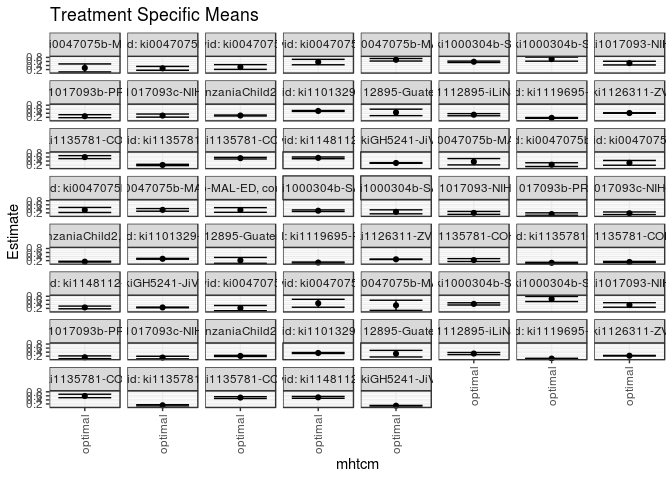

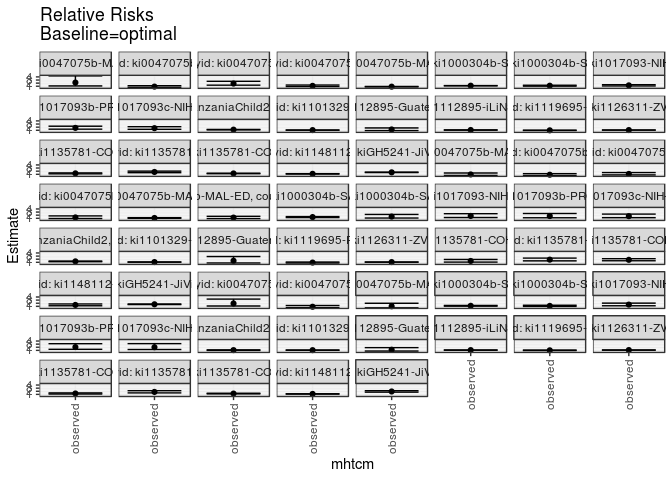

## Results Table

### Parameter: TSM

| agecat | studyid | country | intervention_level | baseline_level | estimate | ci_lower | ci_upper |
| --- | --- | --- | --- | --- | --- | --- | --- |
| 0-24 months | ki0047075b-MAL-ED | BANGLADESH | optimal | NA | 0.2800125 | 0.0823640 | 0.4776611 |
| 0-24 months | ki0047075b-MAL-ED | BRAZIL | optimal | NA | 0.2606933 | 0.1650935 | 0.3562931 |
| 0-24 months | ki0047075b-MAL-ED | INDIA | optimal | NA | 0.3259364 | 0.2082681 | 0.4436047 |
| 0-24 months | ki0047075b-MAL-ED | PERU | optimal | NA | 0.5706324 | 0.4367653 | 0.7044995 |
| 0-24 months | ki0047075b-MAL-ED | SOUTH AFRICA | optimal | NA | 0.6832433 | 0.6203159 | 0.7461707 |
| 0-24 months | ki1000304b-SAS-CompFeed | INDIA | optimal | NA | 0.5845687 | 0.5506357 | 0.6185016 |
| 0-24 months | ki1000304b-SAS-FoodSuppl | INDIA | optimal | NA | 0.7158162 | 0.6144595 | 0.8171730 |
| 0-24 months | ki1017093-NIH-Birth | BANGLADESH | optimal | NA | 0.5191445 | 0.4288483 | 0.6094408 |
| 0-24 months | ki1017093b-PROVIDE | BANGLADESH | optimal | NA | 0.2560479 | 0.1819975 | 0.3300984 |
| 0-24 months | ki1017093c-NIH-Crypto | BANGLADESH | optimal | NA | 0.2861276 | 0.2097333 | 0.3625219 |
| 0-24 months | ki1066203-TanzaniaChild2 | TANZANIA, UNITED REPUBLIC OF | optimal | NA | 0.2892220 | 0.2661549 | 0.3122891 |
| 0-24 months | ki1101329-Keneba | GAMBIA | optimal | NA | 0.5144015 | 0.4925541 | 0.5362490 |
| 0-24 months | ki1112895-Guatemala BSC | GUATEMALA | optimal | NA | 0.4428405 | 0.2826661 | 0.6030150 |
| 0-24 months | ki1112895-iLiNS-Zinc | BURKINA FASO | optimal | NA | 0.3289879 | 0.2761246 | 0.3818512 |
| 0-24 months | ki1119695-PROBIT | BELARUS | optimal | NA | 0.1731587 | 0.1538515 | 0.1924659 |
| 0-24 months | ki1126311-ZVITAMBO | ZIMBABWE | optimal | NA | 0.4125041 | 0.4014691 | 0.4235391 |
| 0-24 months | ki1135781-COHORTS | GUATEMALA | optimal | NA | 0.5940767 | 0.5203928 | 0.6677605 |
| 0-24 months | ki1135781-COHORTS | INDIA | optimal | NA | 0.2064963 | 0.1734624 | 0.2395303 |
| 0-24 months | ki1135781-COHORTS | PHILIPPINES | optimal | NA | 0.5423670 | 0.5032778 | 0.5814561 |
| 0-24 months | ki1148112-LCNI-5 | MALAWI | optimal | NA | 0.5571266 | 0.5141157 | 0.6001374 |
| 0-24 months | kiGH5241-JiVitA-3 | BANGLADESH | optimal | NA | 0.3046942 | 0.2890680 | 0.3203204 |
| 0-6 months | ki0047075b-MAL-ED | BANGLADESH | optimal | NA | 0.3661119 | 0.2090642 | 0.5231596 |
| 0-6 months | ki0047075b-MAL-ED | BRAZIL | optimal | NA | 0.2215160 | 0.1287287 | 0.3143033 |
| 0-6 months | ki0047075b-MAL-ED | INDIA | optimal | NA | 0.3107091 | 0.1928264 | 0.4285918 |
| 0-6 months | ki0047075b-MAL-ED | PERU | optimal | NA | 0.3445352 | 0.2201960 | 0.4688745 |
| 0-6 months | ki0047075b-MAL-ED | SOUTH AFRICA | optimal | NA | 0.3474698 | 0.2819982 | 0.4129414 |
| 0-6 months | ki0047075b-MAL-ED | TANZANIA, UNITED REPUBLIC OF | optimal | NA | 0.3429473 | 0.2274469 | 0.4584476 |
| 0-6 months | ki1000304b-SAS-CompFeed | INDIA | optimal | NA | 0.3067832 | 0.2664786 | 0.3470879 |
| 0-6 months | ki1000304b-SAS-FoodSuppl | INDIA | optimal | NA | 0.2512721 | 0.1525190 | 0.3500253 |
| 0-6 months | ki1017093-NIH-Birth | BANGLADESH | optimal | NA | 0.1987179 | 0.1259055 | 0.2715303 |
| 0-6 months | ki1017093b-PROVIDE | BANGLADESH | optimal | NA | 0.1425203 | 0.0833166 | 0.2017241 |
| 0-6 months | ki1017093c-NIH-Crypto | BANGLADESH | optimal | NA | 0.1803687 | 0.1155758 | 0.2451617 |
| 0-6 months | ki1066203-TanzaniaChild2 | TANZANIA, UNITED REPUBLIC OF | optimal | NA | 0.1487233 | 0.1306197 | 0.1668270 |
| 0-6 months | ki1101329-Keneba | GAMBIA | optimal | NA | 0.2914412 | 0.2704082 | 0.3124742 |
| 0-6 months | ki1112895-Guatemala BSC | GUATEMALA | optimal | NA | 0.2131609 | 0.0672400 | 0.3590817 |
| 0-6 months | ki1119695-PROBIT | BELARUS | optimal | NA | 0.1053739 | 0.0813520 | 0.1293957 |
| 0-6 months | ki1126311-ZVITAMBO | ZIMBABWE | optimal | NA | 0.2659686 | 0.2557279 | 0.2762093 |
| 0-6 months | ki1135781-COHORTS | GUATEMALA | optimal | NA | 0.2278386 | 0.1570731 | 0.2986041 |
| 0-6 months | ki1135781-COHORTS | INDIA | optimal | NA | 0.0921810 | 0.0680738 | 0.1162882 |
| 0-6 months | ki1135781-COHORTS | PHILIPPINES | optimal | NA | 0.1328036 | 0.1064462 | 0.1591610 |
| 0-6 months | ki1148112-LCNI-5 | MALAWI | optimal | NA | 0.2477096 | 0.1805454 | 0.3148738 |
| 0-6 months | kiGH5241-JiVitA-3 | BANGLADESH | optimal | NA | 0.2477665 | 0.2330259 | 0.2625071 |
| 6-24 months | ki0047075b-MAL-ED | INDIA | optimal | NA | 0.2152660 | 0.0855706 | 0.3449613 |
| 6-24 months | ki0047075b-MAL-ED | PERU | optimal | NA | 0.4540985 | 0.2575435 | 0.6506536 |
| 6-24 months | ki0047075b-MAL-ED | SOUTH AFRICA | optimal | NA | 0.3536639 | 0.1034701 | 0.6038577 |
| 6-24 months | ki1000304b-SAS-CompFeed | INDIA | optimal | NA | 0.4225632 | 0.3680002 | 0.4771261 |
| 6-24 months | ki1000304b-SAS-FoodSuppl | INDIA | optimal | NA | 0.6636892 | 0.5397044 | 0.7876741 |
| 6-24 months | ki1017093-NIH-Birth | BANGLADESH | optimal | NA | 0.3696122 | 0.2581149 | 0.4811095 |
| 6-24 months | ki1017093b-PROVIDE | BANGLADESH | optimal | NA | 0.1465313 | 0.0790065 | 0.2140562 |
| 6-24 months | ki1017093c-NIH-Crypto | BANGLADESH | optimal | NA | 0.1312087 | 0.0673797 | 0.1950377 |
| 6-24 months | ki1066203-TanzaniaChild2 | TANZANIA, UNITED REPUBLIC OF | optimal | NA | 0.2119216 | 0.1838201 | 0.2400231 |
| 6-24 months | ki1101329-Keneba | GAMBIA | optimal | NA | 0.3578252 | 0.3329521 | 0.3826983 |
| 6-24 months | ki1112895-Guatemala BSC | GUATEMALA | optimal | NA | 0.3235455 | 0.1611366 | 0.4859543 |
| 6-24 months | ki1112895-iLiNS-Zinc | BURKINA FASO | optimal | NA | 0.3292433 | 0.2765082 | 0.3819785 |
| 6-24 months | ki1119695-PROBIT | BELARUS | optimal | NA | 0.0792740 | 0.0638270 | 0.0947209 |
| 6-24 months | ki1126311-ZVITAMBO | ZIMBABWE | optimal | NA | 0.2225352 | 0.2104476 | 0.2346227 |
| 6-24 months | ki1135781-COHORTS | GUATEMALA | optimal | NA | 0.5936663 | 0.5077564 | 0.6795763 |
| 6-24 months | ki1135781-COHORTS | INDIA | optimal | NA | 0.1335470 | 0.1039882 | 0.1631059 |
| 6-24 months | ki1135781-COHORTS | PHILIPPINES | optimal | NA | 0.5138320 | 0.4698270 | 0.5578369 |
| 6-24 months | ki1148112-LCNI-5 | MALAWI | optimal | NA | 0.5255252 | 0.4800612 | 0.5709891 |
| 6-24 months | kiGH5241-JiVitA-3 | BANGLADESH | optimal | NA | 0.1128621 | 0.0982764 | 0.1274478 |

### Parameter: E(Y)

| agecat | studyid | country | intervention_level | baseline_level | estimate | ci_lower | ci_upper |
| --- | --- | --- | --- | --- | --- | --- | --- |
| 0-24 months | ki0047075b-MAL-ED | BANGLADESH | observed | NA | 0.6102362 | 0.5501413 | 0.6703311 |
| 0-24 months | ki0047075b-MAL-ED | BRAZIL | observed | NA | 0.2297297 | 0.1742694 | 0.2851900 |
| 0-24 months | ki0047075b-MAL-ED | INDIA | observed | NA | 0.6074380 | 0.5457864 | 0.6690897 |
| 0-24 months | ki0047075b-MAL-ED | PERU | observed | NA | 0.6413793 | 0.5860858 | 0.6966728 |
| 0-24 months | ki0047075b-MAL-ED | SOUTH AFRICA | observed | NA | 0.5888889 | 0.5300901 | 0.6476877 |
| 0-24 months | ki1000304b-SAS-CompFeed | INDIA | observed | NA | 0.6865672 | 0.6433613 | 0.7297731 |
| 0-24 months | ki1000304b-SAS-FoodSuppl | INDIA | observed | NA | 0.8386308 | 0.8029353 | 0.8743263 |
| 0-24 months | ki1017093-NIH-Birth | BANGLADESH | observed | NA | 0.6645469 | 0.6276196 | 0.7014742 |
| 0-24 months | ki1017093b-PROVIDE | BANGLADESH | observed | NA | 0.4514200 | 0.4136828 | 0.4891573 |
| 0-24 months | ki1017093c-NIH-Crypto | BANGLADESH | observed | NA | 0.4794702 | 0.4438115 | 0.5151289 |
| 0-24 months | ki1066203-TanzaniaChild2 | TANZANIA, UNITED REPUBLIC OF | observed | NA | 0.3454854 | 0.3262920 | 0.3646787 |
| 0-24 months | ki1101329-Keneba | GAMBIA | observed | NA | 0.5419753 | 0.5221615 | 0.5617891 |
| 0-24 months | ki1112895-Guatemala BSC | GUATEMALA | observed | NA | 0.5574468 | 0.4938076 | 0.6210860 |
| 0-24 months | ki1112895-iLiNS-Zinc | BURKINA FASO | observed | NA | 0.3559962 | 0.3060347 | 0.4059578 |
| 0-24 months | ki1119695-PROBIT | BELARUS | observed | NA | 0.1692151 | 0.1502685 | 0.1881616 |
| 0-24 months | ki1126311-ZVITAMBO | ZIMBABWE | observed | NA | 0.4388957 | 0.4290960 | 0.4486953 |
| 0-24 months | ki1135781-COHORTS | GUATEMALA | observed | NA | 0.7662539 | 0.7431681 | 0.7893396 |
| 0-24 months | ki1135781-COHORTS | INDIA | observed | NA | 0.3599161 | 0.3383625 | 0.3814696 |
| 0-24 months | ki1135781-COHORTS | PHILIPPINES | observed | NA | 0.6863963 | 0.6699497 | 0.7028430 |
| 0-24 months | ki1148112-LCNI-5 | MALAWI | observed | NA | 0.6356033 | 0.6029802 | 0.6682264 |
| 0-24 months | kiGH5241-JiVitA-3 | BANGLADESH | observed | NA | 0.4940621 | 0.4862037 | 0.5019205 |
| 0-6 months | ki0047075b-MAL-ED | BANGLADESH | observed | NA | 0.3464567 | 0.2878227 | 0.4050907 |
| 0-6 months | ki0047075b-MAL-ED | BRAZIL | observed | NA | 0.1891892 | 0.1375523 | 0.2408261 |
| 0-6 months | ki0047075b-MAL-ED | INDIA | observed | NA | 0.3429752 | 0.2830428 | 0.4029076 |
| 0-6 months | ki0047075b-MAL-ED | PERU | observed | NA | 0.4413793 | 0.3841309 | 0.4986278 |
| 0-6 months | ki0047075b-MAL-ED | SOUTH AFRICA | observed | NA | 0.3814815 | 0.3234338 | 0.4395292 |
| 0-6 months | ki0047075b-MAL-ED | TANZANIA, UNITED REPUBLIC OF | observed | NA | 0.4179688 | 0.3574314 | 0.4785061 |
| 0-6 months | ki1000304b-SAS-CompFeed | INDIA | observed | NA | 0.4266382 | 0.3925570 | 0.4607194 |
| 0-6 months | ki1000304b-SAS-FoodSuppl | INDIA | observed | NA | 0.3906634 | 0.3432048 | 0.4381220 |
| 0-6 months | ki1017093-NIH-Birth | BANGLADESH | observed | NA | 0.3497615 | 0.3124631 | 0.3870600 |
| 0-6 months | ki1017093b-PROVIDE | BANGLADESH | observed | NA | 0.2466368 | 0.2139486 | 0.2793250 |
| 0-6 months | ki1017093c-NIH-Crypto | BANGLADESH | observed | NA | 0.3033113 | 0.2704998 | 0.3361228 |
| 0-6 months | ki1066203-TanzaniaChild2 | TANZANIA, UNITED REPUBLIC OF | observed | NA | 0.1937262 | 0.1777743 | 0.2096780 |
| 0-6 months | ki1101329-Keneba | GAMBIA | observed | NA | 0.3141798 | 0.2945906 | 0.3337690 |
| 0-6 months | ki1112895-Guatemala BSC | GUATEMALA | observed | NA | 0.3196347 | 0.2577308 | 0.3815386 |
| 0-6 months | ki1119695-PROBIT | BELARUS | observed | NA | 0.0969856 | 0.0839703 | 0.1100009 |
| 0-6 months | ki1126311-ZVITAMBO | ZIMBABWE | observed | NA | 0.2859756 | 0.2770468 | 0.2949044 |
| 0-6 months | ki1135781-COHORTS | GUATEMALA | observed | NA | 0.3261682 | 0.2980650 | 0.3542714 |
| 0-6 months | ki1135781-COHORTS | INDIA | observed | NA | 0.1714744 | 0.1543953 | 0.1885534 |
| 0-6 months | ki1135781-COHORTS | PHILIPPINES | observed | NA | 0.2390451 | 0.2239262 | 0.2541640 |
| 0-6 months | ki1148112-LCNI-5 | MALAWI | observed | NA | 0.3579336 | 0.3007518 | 0.4151153 |
| 0-6 months | kiGH5241-JiVitA-3 | BANGLADESH | observed | NA | 0.4108991 | 0.4034353 | 0.4183630 |
| 6-24 months | ki0047075b-MAL-ED | INDIA | observed | NA | 0.4129032 | 0.3351414 | 0.4906651 |
| 6-24 months | ki0047075b-MAL-ED | PERU | observed | NA | 0.3918919 | 0.3129763 | 0.4708075 |
| 6-24 months | ki0047075b-MAL-ED | SOUTH AFRICA | observed | NA | 0.3589744 | 0.2834562 | 0.4344926 |
| 6-24 months | ki1000304b-SAS-CompFeed | INDIA | observed | NA | 0.4939435 | 0.4498186 | 0.5380683 |
| 6-24 months | ki1000304b-SAS-FoodSuppl | INDIA | observed | NA | 0.7572016 | 0.7031798 | 0.8112234 |
| 6-24 months | ki1017093-NIH-Birth | BANGLADESH | observed | NA | 0.5739130 | 0.5216565 | 0.6261696 |
| 6-24 months | ki1017093b-PROVIDE | BANGLADESH | observed | NA | 0.2997812 | 0.2577294 | 0.3418330 |
| 6-24 months | ki1017093c-NIH-Crypto | BANGLADESH | observed | NA | 0.2628458 | 0.2244546 | 0.3012371 |
| 6-24 months | ki1066203-TanzaniaChild2 | TANZANIA, UNITED REPUBLIC OF | observed | NA | 0.2268695 | 0.2061992 | 0.2475397 |
| 6-24 months | ki1101329-Keneba | GAMBIA | observed | NA | 0.3805837 | 0.3573526 | 0.4038147 |
| 6-24 months | ki1112895-Guatemala BSC | GUATEMALA | observed | NA | 0.3885350 | 0.3120482 | 0.4650219 |
| 6-24 months | ki1112895-iLiNS-Zinc | BURKINA FASO | observed | NA | 0.3559962 | 0.3060347 | 0.4059578 |
| 6-24 months | ki1119695-PROBIT | BELARUS | observed | NA | 0.0800387 | 0.0658162 | 0.0942612 |
| 6-24 months | ki1126311-ZVITAMBO | ZIMBABWE | observed | NA | 0.2439024 | 0.2332045 | 0.2546004 |
| 6-24 months | ki1135781-COHORTS | GUATEMALA | observed | NA | 0.7612827 | 0.7324712 | 0.7900941 |
| 6-24 months | ki1135781-COHORTS | INDIA | observed | NA | 0.2385621 | 0.2171991 | 0.2599251 |
| 6-24 months | ki1135781-COHORTS | PHILIPPINES | observed | NA | 0.6449788 | 0.6246093 | 0.6653483 |
| 6-24 months | ki1148112-LCNI-5 | MALAWI | observed | NA | 0.5983494 | 0.5626894 | 0.6340094 |
| 6-24 months | kiGH5241-JiVitA-3 | BANGLADESH | observed | NA | 0.2174783 | 0.2081017 | 0.2268550 |

### Parameter: RR

| agecat | studyid | country | intervention_level | baseline_level | estimate | ci_lower | ci_upper |
| --- | --- | --- | --- | --- | --- | --- | --- |
| 0-24 months | ki0047075b-MAL-ED | BANGLADESH | observed | optimal | 2.1793175 | 1.0993775 | 4.3201038 |
| 0-24 months | ki0047075b-MAL-ED | BRAZIL | observed | optimal | 0.8812261 | 0.6580813 | 1.1800357 |
| 0-24 months | ki0047075b-MAL-ED | INDIA | observed | optimal | 1.8636705 | 1.3412207 | 2.5896317 |
| 0-24 months | ki0047075b-MAL-ED | PERU | observed | optimal | 1.1239798 | 0.9136787 | 1.3826859 |
| 0-24 months | ki0047075b-MAL-ED | SOUTH AFRICA | observed | optimal | 0.8619022 | 0.8014709 | 0.9268901 |
| 0-24 months | ki1000304b-SAS-CompFeed | INDIA | observed | optimal | 1.1744851 | 1.1388291 | 1.2112575 |
| 0-24 months | ki1000304b-SAS-FoodSuppl | INDIA | observed | optimal | 1.1715727 | 1.0347064 | 1.3265432 |
| 0-24 months | ki1017093-NIH-Birth | BANGLADESH | observed | optimal | 1.2800807 | 1.0948202 | 1.4966901 |
| 0-24 months | ki1017093b-PROVIDE | BANGLADESH | observed | optimal | 1.7630294 | 1.3498959 | 2.3026019 |
| 0-24 months | ki1017093c-NIH-Crypto | BANGLADESH | observed | optimal | 1.6757215 | 1.3081027 | 2.1466530 |
| 0-24 months | ki1066203-TanzaniaChild2 | TANZANIA, UNITED REPUBLIC OF | observed | optimal | 1.1945336 | 1.1337580 | 1.2585671 |
| 0-24 months | ki1101329-Keneba | GAMBIA | observed | optimal | 1.0536036 | 1.0354685 | 1.0720564 |
| 0-24 months | ki1112895-Guatemala BSC | GUATEMALA | observed | optimal | 1.2587981 | 0.9069629 | 1.7471194 |
| 0-24 months | ki1112895-iLiNS-Zinc | BURKINA FASO | observed | optimal | 1.0820951 | 1.0438816 | 1.1217075 |
| 0-24 months | ki1119695-PROBIT | BELARUS | observed | optimal | 0.9772255 | 0.9256781 | 1.0316434 |
| 0-24 months | ki1126311-ZVITAMBO | ZIMBABWE | observed | optimal | 1.0639789 | 1.0501214 | 1.0780193 |
| 0-24 months | ki1135781-COHORTS | GUATEMALA | observed | optimal | 1.2898232 | 1.1497888 | 1.4469126 |
| 0-24 months | ki1135781-COHORTS | INDIA | observed | optimal | 1.7429658 | 1.5112862 | 2.0101619 |
| 0-24 months | ki1135781-COHORTS | PHILIPPINES | observed | optimal | 1.2655571 | 1.1871809 | 1.3491076 |
| 0-24 months | ki1148112-LCNI-5 | MALAWI | observed | optimal | 1.1408599 | 1.0887407 | 1.1954741 |
| 0-24 months | kiGH5241-JiVitA-3 | BANGLADESH | observed | optimal | 1.6215015 | 1.5466940 | 1.6999272 |
| 0-6 months | ki0047075b-MAL-ED | BANGLADESH | observed | optimal | 0.9463137 | 0.6337033 | 1.4131369 |
| 0-6 months | ki0047075b-MAL-ED | BRAZIL | observed | optimal | 0.8540656 | 0.6057447 | 1.2041841 |
| 0-6 months | ki0047075b-MAL-ED | INDIA | observed | optimal | 1.1038466 | 0.7893604 | 1.5436262 |
| 0-6 months | ki0047075b-MAL-ED | PERU | observed | optimal | 1.2810861 | 0.9246374 | 1.7749462 |
| 0-6 months | ki0047075b-MAL-ED | SOUTH AFRICA | observed | optimal | 1.0978838 | 0.9937215 | 1.2129643 |
| 0-6 months | ki0047075b-MAL-ED | TANZANIA, UNITED REPUBLIC OF | observed | optimal | 1.2187552 | 0.9079980 | 1.6358672 |
| 0-6 months | ki1000304b-SAS-CompFeed | INDIA | observed | optimal | 1.3906828 | 1.2394884 | 1.5603201 |
| 0-6 months | ki1000304b-SAS-FoodSuppl | INDIA | observed | optimal | 1.5547422 | 1.0813322 | 2.2354123 |
| 0-6 months | ki1017093-NIH-Birth | BANGLADESH | observed | optimal | 1.7600910 | 1.2494528 | 2.4794217 |
| 0-6 months | ki1017093b-PROVIDE | BANGLADESH | observed | optimal | 1.7305376 | 1.1760006 | 2.5465636 |
| 0-6 months | ki1017093c-NIH-Crypto | BANGLADESH | observed | optimal | 1.6816177 | 1.2016937 | 2.3532104 |
| 0-6 months | ki1066203-TanzaniaChild2 | TANZANIA, UNITED REPUBLIC OF | observed | optimal | 1.3025941 | 1.1962576 | 1.4183830 |
| 0-6 months | ki1101329-Keneba | GAMBIA | observed | optimal | 1.0780212 | 1.0435105 | 1.1136733 |
| 0-6 months | ki1112895-Guatemala BSC | GUATEMALA | observed | optimal | 1.4994998 | 0.7865524 | 2.8586775 |
| 0-6 months | ki1119695-PROBIT | BELARUS | observed | optimal | 0.9203950 | 0.7817164 | 1.0836755 |
| 0-6 months | ki1126311-ZVITAMBO | ZIMBABWE | observed | optimal | 1.0752232 | 1.0525345 | 1.0984010 |
| 0-6 months | ki1135781-COHORTS | GUATEMALA | observed | optimal | 1.4315758 | 1.0688069 | 1.9174738 |
| 0-6 months | ki1135781-COHORTS | INDIA | observed | optimal | 1.8601923 | 1.4669285 | 2.3588848 |
| 0-6 months | ki1135781-COHORTS | PHILIPPINES | observed | optimal | 1.7999894 | 1.4958576 | 2.1659562 |
| 0-6 months | ki1148112-LCNI-5 | MALAWI | observed | optimal | 1.4449727 | 1.1870912 | 1.7588760 |
| 0-6 months | kiGH5241-JiVitA-3 | BANGLADESH | observed | optimal | 1.6584126 | 1.5687530 | 1.7531965 |
| 6-24 months | ki0047075b-MAL-ED | INDIA | observed | optimal | 1.9181074 | 1.1084869 | 3.3190614 |
| 6-24 months | ki0047075b-MAL-ED | PERU | observed | optimal | 0.8630107 | 0.5901871 | 1.2619514 |
| 6-24 months | ki0047075b-MAL-ED | SOUTH AFRICA | observed | optimal | 1.0150155 | 0.5186861 | 1.9862815 |
| 6-24 months | ki1000304b-SAS-CompFeed | INDIA | observed | optimal | 1.1689222 | 1.0651401 | 1.2828164 |
| 6-24 months | ki1000304b-SAS-FoodSuppl | INDIA | observed | optimal | 1.1408979 | 0.9712579 | 1.3401672 |
| 6-24 months | ki1017093-NIH-Birth | BANGLADESH | observed | optimal | 1.5527437 | 1.1885849 | 2.0284736 |
| 6-24 months | ki1017093b-PROVIDE | BANGLADESH | observed | optimal | 2.0458502 | 1.3331819 | 3.1394839 |
| 6-24 months | ki1017093c-NIH-Crypto | BANGLADESH | observed | optimal | 2.0032658 | 1.2726199 | 3.1533954 |
| 6-24 months | ki1066203-TanzaniaChild2 | TANZANIA, UNITED REPUBLIC OF | observed | optimal | 1.0705349 | 0.9767178 | 1.1733634 |
| 6-24 months | ki1101329-Keneba | GAMBIA | observed | optimal | 1.0636022 | 1.0333600 | 1.0947294 |
| 6-24 months | ki1112895-Guatemala BSC | GUATEMALA | observed | optimal | 1.2008669 | 0.7705940 | 1.8713892 |
| 6-24 months | ki1112895-iLiNS-Zinc | BURKINA FASO | observed | optimal | 1.0812556 | 1.0435986 | 1.1202716 |
| 6-24 months | ki1119695-PROBIT | BELARUS | observed | optimal | 1.0096468 | 0.9339907 | 1.0914312 |
| 6-24 months | ki1126311-ZVITAMBO | ZIMBABWE | observed | optimal | 1.0960175 | 1.0631978 | 1.1298504 |
| 6-24 months | ki1135781-COHORTS | GUATEMALA | observed | optimal | 1.2823410 | 1.1229830 | 1.4643127 |
| 6-24 months | ki1135781-COHORTS | INDIA | observed | optimal | 1.7863526 | 1.4660260 | 2.1766706 |
| 6-24 months | ki1135781-COHORTS | PHILIPPINES | observed | optimal | 1.2552328 | 1.1648459 | 1.3526333 |
| 6-24 months | ki1148112-LCNI-5 | MALAWI | observed | optimal | 1.1385742 | 1.0816706 | 1.1984713 |
| 6-24 months | kiGH5241-JiVitA-3 | BANGLADESH | observed | optimal | 1.9269387 | 1.7090072 | 2.1726607 |

### Parameter: PAR

| agecat | studyid | country | intervention_level | baseline_level | estimate | ci_lower | ci_upper |
| --- | --- | --- | --- | --- | --- | --- | --- |
| 0-24 months | ki0047075b-MAL-ED | BANGLADESH | optimal | NA | 0.3302237 | 0.1407739 | 0.5196735 |
| 0-24 months | ki0047075b-MAL-ED | BRAZIL | optimal | NA | -0.0309636 | -0.1069689 | 0.0450418 |
| 0-24 months | ki0047075b-MAL-ED | INDIA | optimal | NA | 0.2815016 | 0.1755336 | 0.3874696 |
| 0-24 months | ki0047075b-MAL-ED | PERU | optimal | NA | 0.0707469 | -0.0468154 | 0.1883093 |
| 0-24 months | ki0047075b-MAL-ED | SOUTH AFRICA | optimal | NA | -0.0943544 | -0.1403877 | -0.0483211 |
| 0-24 months | ki1000304b-SAS-CompFeed | INDIA | optimal | NA | 0.1019985 | 0.0806005 | 0.1233965 |
| 0-24 months | ki1000304b-SAS-FoodSuppl | INDIA | optimal | NA | 0.1228146 | 0.0351306 | 0.2104985 |
| 0-24 months | ki1017093-NIH-Birth | BANGLADESH | optimal | NA | 0.1454024 | 0.0651126 | 0.2256921 |
| 0-24 months | ki1017093b-PROVIDE | BANGLADESH | optimal | NA | 0.1953721 | 0.1270155 | 0.2637287 |
| 0-24 months | ki1017093c-NIH-Crypto | BANGLADESH | optimal | NA | 0.1933426 | 0.1227439 | 0.2639413 |
| 0-24 months | ki1066203-TanzaniaChild2 | TANZANIA, UNITED REPUBLIC OF | optimal | NA | 0.0562634 | 0.0411325 | 0.0713942 |
| 0-24 months | ki1101329-Keneba | GAMBIA | optimal | NA | 0.0275738 | 0.0187177 | 0.0364299 |
| 0-24 months | ki1112895-Guatemala BSC | GUATEMALA | optimal | NA | 0.1146063 | -0.0293401 | 0.2585526 |
| 0-24 months | ki1112895-iLiNS-Zinc | BURKINA FASO | optimal | NA | 0.0270083 | 0.0164561 | 0.0375605 |
| 0-24 months | ki1119695-PROBIT | BELARUS | optimal | NA | -0.0039436 | -0.0132264 | 0.0053392 |
| 0-24 months | ki1126311-ZVITAMBO | ZIMBABWE | optimal | NA | 0.0263916 | 0.0209972 | 0.0317860 |
| 0-24 months | ki1135781-COHORTS | GUATEMALA | optimal | NA | 0.1721772 | 0.1046586 | 0.2396958 |
| 0-24 months | ki1135781-COHORTS | INDIA | optimal | NA | 0.1534197 | 0.1234339 | 0.1834056 |
| 0-24 months | ki1135781-COHORTS | PHILIPPINES | optimal | NA | 0.1440294 | 0.1097867 | 0.1782721 |
| 0-24 months | ki1148112-LCNI-5 | MALAWI | optimal | NA | 0.0784768 | 0.0530779 | 0.1038757 |
| 0-24 months | kiGH5241-JiVitA-3 | BANGLADESH | optimal | NA | 0.1893679 | 0.1749543 | 0.2037815 |
| 0-6 months | ki0047075b-MAL-ED | BANGLADESH | optimal | NA | -0.0196552 | -0.1663682 | 0.1270577 |
| 0-6 months | ki0047075b-MAL-ED | BRAZIL | optimal | NA | -0.0323268 | -0.1081365 | 0.0434829 |
| 0-6 months | ki0047075b-MAL-ED | INDIA | optimal | NA | 0.0322661 | -0.0720313 | 0.1365635 |
| 0-6 months | ki0047075b-MAL-ED | PERU | optimal | NA | 0.0968441 | -0.0151427 | 0.2088309 |
| 0-6 months | ki0047075b-MAL-ED | SOUTH AFRICA | optimal | NA | 0.0340117 | -0.0006001 | 0.0686234 |
| 0-6 months | ki0047075b-MAL-ED | TANZANIA, UNITED REPUBLIC OF | optimal | NA | 0.0750215 | -0.0257669 | 0.1758099 |
| 0-6 months | ki1000304b-SAS-CompFeed | INDIA | optimal | NA | 0.1198549 | 0.0820990 | 0.1576109 |
| 0-6 months | ki1000304b-SAS-FoodSuppl | INDIA | optimal | NA | 0.1393913 | 0.0480853 | 0.2306972 |
| 0-6 months | ki1017093-NIH-Birth | BANGLADESH | optimal | NA | 0.1510437 | 0.0822549 | 0.2198324 |
| 0-6 months | ki1017093b-PROVIDE | BANGLADESH | optimal | NA | 0.1041165 | 0.0481139 | 0.1601190 |
| 0-6 months | ki1017093c-NIH-Crypto | BANGLADESH | optimal | NA | 0.1229425 | 0.0616885 | 0.1841966 |
| 0-6 months | ki1066203-TanzaniaChild2 | TANZANIA, UNITED REPUBLIC OF | optimal | NA | 0.0450028 | 0.0320072 | 0.0579984 |
| 0-6 months | ki1101329-Keneba | GAMBIA | optimal | NA | 0.0227386 | 0.0132417 | 0.0322355 |
| 0-6 months | ki1112895-Guatemala BSC | GUATEMALA | optimal | NA | 0.1064738 | -0.0313884 | 0.2443361 |
| 0-6 months | ki1119695-PROBIT | BELARUS | optimal | NA | -0.0083883 | -0.0258196 | 0.0090430 |
| 0-6 months | ki1126311-ZVITAMBO | ZIMBABWE | optimal | NA | 0.0200070 | 0.0143250 | 0.0256890 |
| 0-6 months | ki1135781-COHORTS | GUATEMALA | optimal | NA | 0.0983296 | 0.0318220 | 0.1648372 |
| 0-6 months | ki1135781-COHORTS | INDIA | optimal | NA | 0.0792934 | 0.0563447 | 0.1022420 |
| 0-6 months | ki1135781-COHORTS | PHILIPPINES | optimal | NA | 0.1062415 | 0.0810763 | 0.1314067 |
| 0-6 months | ki1148112-LCNI-5 | MALAWI | optimal | NA | 0.1102240 | 0.0609689 | 0.1594791 |
| 0-6 months | kiGH5241-JiVitA-3 | BANGLADESH | optimal | NA | 0.1631326 | 0.1492204 | 0.1770448 |
| 6-24 months | ki0047075b-MAL-ED | INDIA | optimal | NA | 0.1976373 | 0.0785715 | 0.3167030 |
| 6-24 months | ki0047075b-MAL-ED | PERU | optimal | NA | -0.0622067 | -0.2354096 | 0.1109963 |
| 6-24 months | ki0047075b-MAL-ED | SOUTH AFRICA | optimal | NA | 0.0053105 | -0.2321064 | 0.2427273 |
| 6-24 months | ki1000304b-SAS-CompFeed | INDIA | optimal | NA | 0.0713803 | 0.0315964 | 0.1111642 |
| 6-24 months | ki1000304b-SAS-FoodSuppl | INDIA | optimal | NA | 0.0935124 | -0.0124007 | 0.1994255 |
| 6-24 months | ki1017093-NIH-Birth | BANGLADESH | optimal | NA | 0.2043008 | 0.1081122 | 0.3004894 |
| 6-24 months | ki1017093b-PROVIDE | BANGLADESH | optimal | NA | 0.1532498 | 0.0885094 | 0.2179903 |
| 6-24 months | ki1017093c-NIH-Crypto | BANGLADESH | optimal | NA | 0.1316372 | 0.0704016 | 0.1928728 |
| 6-24 months | ki1066203-TanzaniaChild2 | TANZANIA, UNITED REPUBLIC OF | optimal | NA | 0.0149479 | -0.0044655 | 0.0343612 |
| 6-24 months | ki1101329-Keneba | GAMBIA | optimal | NA | 0.0227585 | 0.0124513 | 0.0330657 |
| 6-24 months | ki1112895-Guatemala BSC | GUATEMALA | optimal | NA | 0.0649896 | -0.0779147 | 0.2078938 |
| 6-24 months | ki1112895-iLiNS-Zinc | BURKINA FASO | optimal | NA | 0.0267529 | 0.0163176 | 0.0371881 |
| 6-24 months | ki1119695-PROBIT | BELARUS | optimal | NA | 0.0007647 | -0.0054098 | 0.0069392 |
| 6-24 months | ki1126311-ZVITAMBO | ZIMBABWE | optimal | NA | 0.0213673 | 0.0145729 | 0.0281617 |
| 6-24 months | ki1135781-COHORTS | GUATEMALA | optimal | NA | 0.1676163 | 0.0897879 | 0.2454448 |
| 6-24 months | ki1135781-COHORTS | INDIA | optimal | NA | 0.1050151 | 0.0774820 | 0.1325481 |
| 6-24 months | ki1135781-COHORTS | PHILIPPINES | optimal | NA | 0.1311468 | 0.0931860 | 0.1691076 |
| 6-24 months | ki1148112-LCNI-5 | MALAWI | optimal | NA | 0.0728242 | 0.0464632 | 0.0991853 |
| 6-24 months | kiGH5241-JiVitA-3 | BANGLADESH | optimal | NA | 0.1046162 | 0.0905215 | 0.1187110 |

### Parameter: PAF

| agecat | studyid | country | intervention_level | baseline_level | estimate | ci_lower | ci_upper |
| --- | --- | --- | --- | --- | --- | --- | --- |
| 0-24 months | ki0047075b-MAL-ED | BANGLADESH | optimal | NA | 0.5411407 | 0.0903943 | 0.7685241 |
| 0-24 months | ki0047075b-MAL-ED | BRAZIL | optimal | NA | -0.1347826 | -0.5195691 | 0.1525680 |
| 0-24 months | ki0047075b-MAL-ED | INDIA | optimal | NA | 0.4634245 | 0.2544106 | 0.6138447 |
| 0-24 months | ki0047075b-MAL-ED | PERU | optimal | NA | 0.1103043 | -0.0944766 | 0.2767699 |
| 0-24 months | ki0047075b-MAL-ED | SOUTH AFRICA | optimal | NA | -0.1602245 | -0.2477060 | -0.0788766 |
| 0-24 months | ki1000304b-SAS-CompFeed | INDIA | optimal | NA | 0.1485630 | 0.1219051 | 0.1744117 |
| 0-24 months | ki1000304b-SAS-FoodSuppl | INDIA | optimal | NA | 0.1464465 | 0.0335422 | 0.2461610 |
| 0-24 months | ki1017093-NIH-Birth | BANGLADESH | optimal | NA | 0.2187992 | 0.0866080 | 0.3318590 |
| 0-24 months | ki1017093b-PROVIDE | BANGLADESH | optimal | NA | 0.4327945 | 0.2592021 | 0.5657087 |
| 0-24 months | ki1017093c-NIH-Crypto | BANGLADESH | optimal | NA | 0.4032421 | 0.2355340 | 0.5341585 |
| 0-24 months | ki1066203-TanzaniaChild2 | TANZANIA, UNITED REPUBLIC OF | optimal | NA | 0.1628532 | 0.1179775 | 0.2054456 |
| 0-24 months | ki1101329-Keneba | GAMBIA | optimal | NA | 0.0508765 | 0.0342536 | 0.0672132 |
| 0-24 months | ki1112895-Guatemala BSC | GUATEMALA | optimal | NA | 0.2055914 | -0.1025809 | 0.4276293 |
| 0-24 months | ki1112895-iLiNS-Zinc | BURKINA FASO | optimal | NA | 0.0758668 | 0.0420369 | 0.1085020 |
| 0-24 months | ki1119695-PROBIT | BELARUS | optimal | NA | -0.0233053 | -0.0802892 | 0.0306728 |
| 0-24 months | ki1126311-ZVITAMBO | ZIMBABWE | optimal | NA | 0.0601317 | 0.0477292 | 0.0723728 |
| 0-24 months | ki1135781-COHORTS | GUATEMALA | optimal | NA | 0.2247000 | 0.1302751 | 0.3088733 |
| 0-24 months | ki1135781-COHORTS | INDIA | optimal | NA | 0.4262653 | 0.3383120 | 0.5025276 |
| 0-24 months | ki1135781-COHORTS | PHILIPPINES | optimal | NA | 0.2098341 | 0.1576684 | 0.2587693 |
| 0-24 months | ki1148112-LCNI-5 | MALAWI | optimal | NA | 0.1234682 | 0.0815077 | 0.1635117 |
| 0-24 months | kiGH5241-JiVitA-3 | BANGLADESH | optimal | NA | 0.3832877 | 0.3534597 | 0.4117395 |
| 0-6 months | ki0047075b-MAL-ED | BANGLADESH | optimal | NA | -0.0567321 | -0.5780255 | 0.2923545 |
| 0-6 months | ki0047075b-MAL-ED | BRAZIL | optimal | NA | -0.1708702 | -0.6508606 | 0.1695622 |
| 0-6 months | ki0047075b-MAL-ED | INDIA | optimal | NA | 0.0940770 | -0.2668485 | 0.3521748 |
| 0-6 months | ki0047075b-MAL-ED | PERU | optimal | NA | 0.2194123 | -0.0815050 | 0.4366026 |
| 0-6 months | ki0047075b-MAL-ED | SOUTH AFRICA | optimal | NA | 0.0891568 | -0.0063181 | 0.1755734 |
| 0-6 months | ki0047075b-MAL-ED | TANZANIA, UNITED REPUBLIC OF | optimal | NA | 0.1794907 | -0.1013240 | 0.3887034 |
| 0-6 months | ki1000304b-SAS-CompFeed | INDIA | optimal | NA | 0.2809288 | 0.1932155 | 0.3591059 |
| 0-6 months | ki1000304b-SAS-FoodSuppl | INDIA | optimal | NA | 0.3568065 | 0.0752148 | 0.5526552 |
| 0-6 months | ki1017093-NIH-Birth | BANGLADESH | optimal | NA | 0.4318476 | 0.1996496 | 0.5966801 |
| 0-6 months | ki1017093b-PROVIDE | BANGLADESH | optimal | NA | 0.4221449 | 0.1496603 | 0.6073139 |
| 0-6 months | ki1017093c-NIH-Crypto | BANGLADESH | optimal | NA | 0.4053345 | 0.1678412 | 0.5750486 |
| 0-6 months | ki1066203-TanzaniaChild2 | TANZANIA, UNITED REPUBLIC OF | optimal | NA | 0.2323012 | 0.1640597 | 0.2949718 |
| 0-6 months | ki1101329-Keneba | GAMBIA | optimal | NA | 0.0723745 | 0.0416963 | 0.1020706 |
| 0-6 months | ki1112895-Guatemala BSC | GUATEMALA | optimal | NA | 0.3331110 | -0.2713711 | 0.6501879 |
| 0-6 months | ki1119695-PROBIT | BELARUS | optimal | NA | -0.0864901 | -0.2792363 | 0.0772145 |
| 0-6 months | ki1126311-ZVITAMBO | ZIMBABWE | optimal | NA | 0.0699606 | 0.0499124 | 0.0895857 |
| 0-6 months | ki1135781-COHORTS | GUATEMALA | optimal | NA | 0.3014690 | 0.0643773 | 0.4784805 |
| 0-6 months | ki1135781-COHORTS | INDIA | optimal | NA | 0.4624212 | 0.3183035 | 0.5760709 |
| 0-6 months | ki1135781-COHORTS | PHILIPPINES | optimal | NA | 0.4444412 | 0.3314872 | 0.5383101 |
| 0-6 months | ki1148112-LCNI-5 | MALAWI | optimal | NA | 0.3079454 | 0.1576047 | 0.4314551 |
| 0-6 months | kiGH5241-JiVitA-3 | BANGLADESH | optimal | NA | 0.3970137 | 0.3625510 | 0.4296133 |
| 6-24 months | ki0047075b-MAL-ED | INDIA | optimal | NA | 0.4786528 | 0.0978693 | 0.6987100 |
| 6-24 months | ki0047075b-MAL-ED | PERU | optimal | NA | -0.1587342 | -0.6943779 | 0.2075764 |
| 6-24 months | ki0047075b-MAL-ED | SOUTH AFRICA | optimal | NA | 0.0147934 | -0.9279484 | 0.4965467 |
| 6-24 months | ki1000304b-SAS-CompFeed | INDIA | optimal | NA | 0.1445111 | 0.0611564 | 0.2204652 |
| 6-24 months | ki1000304b-SAS-FoodSuppl | INDIA | optimal | NA | 0.1234974 | -0.0295927 | 0.2538245 |
| 6-24 months | ki1017093-NIH-Birth | BANGLADESH | optimal | NA | 0.3559787 | 0.1586634 | 0.5070185 |
| 6-24 months | ki1017093b-PROVIDE | BANGLADESH | optimal | NA | 0.5112057 | 0.2499148 | 0.6814763 |
| 6-24 months | ki1017093c-NIH-Crypto | BANGLADESH | optimal | NA | 0.5008151 | 0.2142194 | 0.6828815 |
| 6-24 months | ki1066203-TanzaniaChild2 | TANZANIA, UNITED REPUBLIC OF | optimal | NA | 0.0658875 | -0.0238372 | 0.1477491 |
| 6-24 months | ki1101329-Keneba | GAMBIA | optimal | NA | 0.0597989 | 0.0322831 | 0.0865323 |
| 6-24 months | ki1112895-Guatemala BSC | GUATEMALA | optimal | NA | 0.1672682 | -0.2977003 | 0.4656376 |
| 6-24 months | ki1112895-iLiNS-Zinc | BURKINA FASO | optimal | NA | 0.0751493 | 0.0417771 | 0.1073593 |
| 6-24 months | ki1119695-PROBIT | BELARUS | optimal | NA | 0.0095546 | -0.0706745 | 0.0837719 |
| 6-24 months | ki1126311-ZVITAMBO | ZIMBABWE | optimal | NA | 0.0876058 | 0.0594412 | 0.1149271 |
| 6-24 months | ki1135781-COHORTS | GUATEMALA | optimal | NA | 0.2201762 | 0.1095146 | 0.3170858 |
| 6-24 months | ki1135781-COHORTS | INDIA | optimal | NA | 0.4402001 | 0.3178839 | 0.5405828 |
| 6-24 months | ki1135781-COHORTS | PHILIPPINES | optimal | NA | 0.2033350 | 0.1415174 | 0.2607013 |
| 6-24 months | ki1148112-LCNI-5 | MALAWI | optimal | NA | 0.1217085 | 0.0755041 | 0.1656037 |
| 6-24 months | kiGH5241-JiVitA-3 | BANGLADESH | optimal | NA | 0.4810421 | 0.4148649 | 0.5397349 |